# Homework #10

Nicole R Gorman

5 April 2024

#For loops and randomization tests

- Open libraries

```r
library(tidyverse)
library(ggplot2)
library(MASS)
library(gridExtra)
```

1. Using a for loop, write a function to calculate the number of zeroes in a numeric vector. Before entering the loop, set up a counter variable counter <- 0. Inside the loop, add 1 to counter each time you have a zero in the vector. Finally, use return(counter) for the output.

```r
vec <- rbinom (n=5, size=1, 0.5)
counter <- 0
# create a vector w/ 0's and set up a counter variable

##########################################################################
# FUNCTION count_zeros
# count the number of zeros in a vector
# input: vector with zeros
# output: number of variables = 0
#----------------------------------------------------------------

count_zeros <- function(vec) {
 for (i in vec) {
   if(i==0) {
   counter <- counter + 1
}
   return(counter)
}
}

# end of count_zeros function
##########################################################################

count_zeros(vec)
```

```
## [1] 1
```

2. Use subsetting instead of a loop to rewrite the function as a single line of code.

```r
vec <- rbinom (n=5, size=1, 0.5)
counter <- 0

##########################################################################
# FUNCTION count_zeros2
# count the number of zeros in a vector
# input: vector with zeros
# output: number of variables = 0
#----------------------------------------------------------------

count_zeros2 <- function(vec) {
   return(sum(vec==0))
}

# end of count_zeros2 function
##########################################################################

result <- count_zeros2(vec)
print (result)
```

```
## [1] 2
```

```r
# call function and print result
```

3. Write a function that takes as input two integers representing the number of rows and columns in a matrix. The output is a matrix of these dimensions in which each element is the product of the row number x the column number.

```r
##########################################################################
# FUNCTION prod_matrix
# create matrix with elements as products of row and column
# input: number of rows and columns
# output: matrix of products
#----------------------------------------------------------------

prod_matrix <- function(nRow,nCol) {
   my_mat <- matrix(0, nrow = nRow, ncol = nCol)

  for (i in 1:nRow) {
    for (j in 1:nCol) {
       my_mat[i,j] <- i * j
  }

}
  return(my_mat)
}

# end of prod_matrix function
##########################################################################

my_matrix <- prod_matrix(3,4)
print (my_matrix)
```

```
##      [,1] [,2] [,3] [,4]
## [1,]    1    2    3    4
## [2,]    2    4    6    8
## [3,]    3    6    9   12
```

4. Now let’s practice calling custom functions within a for loops. Use the code from previous lectures on loops and functions to complete the following steps:
1. Simulate a dataset with 3 groups of data, each group drawn from a distribution with a different mean. The final data frame should have 1 column for group and 1 column for the response variable.

```r
# Set seed for reproducibility
set.seed(1)

# Simulate data for each group
group1 <- rnorm(50, mean = 10, sd = 1)
group2 <- rnorm(50, mean = 15, sd = 1)
group3 <- rnorm(50, mean = 25, sd = 1)

# Combine data into a single dataframe
data <- data.frame(
  group = rep(c("Group1", "Group2", "Group3"), each = 50),
  response = c(group1, group2, group3)
)

head(data)
```

```
##    group  response
## 1 Group1  9.373546
## 2 Group1 10.183643
## 3 Group1  9.164371
## 4 Group1 11.595281
## 5 Group1 10.329508
## 6 Group1  9.179532
```

```r
tail(data)
```

```
##      group response
## 145 Group3 23.88408
## 146 Group3 24.24918
## 147 Group3 27.08717
## 148 Group3 25.01740
## 149 Group3 23.71370
## 150 Group3 23.35939
```

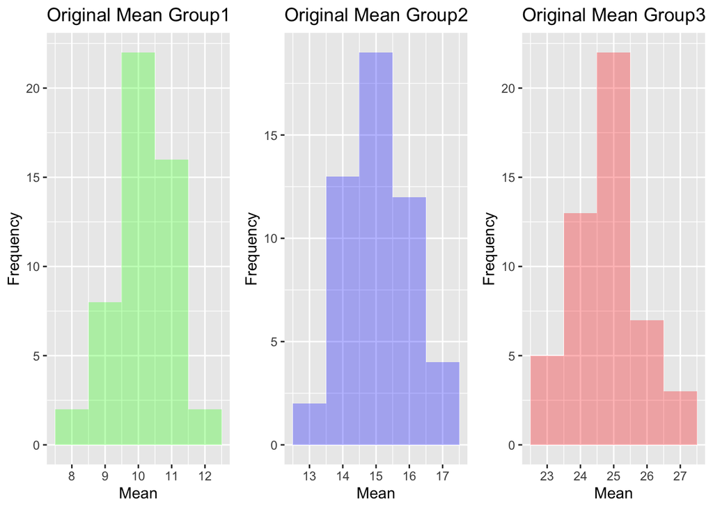

```r
# Create histograms of the means for each group using qplot
foo<-subset(data,group=="Group1")
Ori_Group1 <- qplot(data = foo, x = response, geom = "histogram",
              binwidth = 1, alpha = I(0.3),fill = I("green")) +
   labs(title = "Original Mean Group1", x = "Mean", y = "Frequency")
foo2<-subset(data,group=="Group2")
Ori_Group2 <- qplot(data = foo2, x = response, geom = "histogram",
              binwidth = 1, alpha = I(0.3), fill = I("blue")) +
   labs(title = "Original Mean Group2", x = "Mean", y = "Frequency")

foo3<-subset(data,group=="Group3")
Ori_Group3 <- qplot(data = foo3, x = response, geom = "histogram",
               binwidth = 1, alpha = I(0.3), fill = I("red")) +
   labs(title = "Original Mean Group3", x = "Mean", y = "Frequency")

 # Arrange histograms
grid.arrange(Ori_Group1, Ori_Group2, Ori_Group3, ncol = 3)
```

2. Write a custom function that 1) reshuffles the response variable, and 2) calculates the mean of each group in the reshuffled data. Store the means in a vector of length 3.

```r
##########################################################################
# FUNCTION shuffle_mean
# reshuffle response variable, calculate the mean of each group, store the means in a vector of length 3.
# input: dataset with 3 groups
# output: three group means as vector
#----------------------------------------------------------------

shuffle_mean <- function(data, resVar, groupVar) {

  # reshuffle response variable
  resVar2 <- sample(data[[resVar]])

  # calculate the mean of each group in data2
  meanGroup <- tapply(resVar2, data[[groupVar]], mean)

  # Convert mean_group to a vector of length 3
  meanVector <- numeric(3)
  for (i in 1:3) {
    meanVector[i] <- meanGroup[[i]]
  }

  # Return the vector of means
  return(meanVector)
}

# end of shuffle_mean function
##########################################################################

meanVector <- shuffle_mean(data, "response", "group")

# Print the vector of means
print(meanVector)
```

```
## [1] 15.68769 17.61030 16.76730
```

3. Use a for loop to repeat the function in b 100 times. Store the results in a data frame that has 1 column indicating the replicate number and 1 column for each new group mean, for a total of 4 columns.

```r
# Create an empty data frame to store results
# z <- rep(1:100)
df <- data.frame(repNum = 1:100, Group1 = numeric(100), Group2 = numeric(100), Group3 = numeric(100))

# Repeat the function 100 times
for (i in 1:100) {

  # Call function
  meanVector <- shuffle_mean(data, "response", "group")

  # Add the means to the data frame
  df[i, -1] <- meanVector
}

# Rename columns
colnames(df)[-1] <- paste0("Group", 1:3)

# Print the results data frame
# print(df)
```

4. Use qplot() to create a histogram of the means for each reshuffled group. Or, if you want a challenge, use ggplot() to overlay all 3 histograms in the same figure.

```r
# Create histograms of the means for each group using qplot
new_Group1 <- qplot(data = df, x = Group1, geom = "histogram", cex = .3, binwidth = 1, alpha = I(0.3),fill =I ("green"), show.legend = FALSE)
  labs(title = "Shuffled Mean Group1", x = "Mean", y = "Frequency")
```

```
## $x
## [1] "Mean"
##
## $y
## [1] "Frequency"
##
## $title
## [1] "Shuffled Mean Group1"
##
## attr(,"class")
## [1] "labels"
```